# ANCOVA in Vocabulario (Vocabulario)

Geiser C. Challco geiser@alumni.usp.br

- Descriptive Statistics of Initial Data
- ANCOVA and Pairwise for one factor: **grupo**
  - Without remove non-normal data
  - Computing ANCOVA and PairWise After removing non-normal data (OK)
    - Plots for ancova
    - Checking linearity assumption
    - Checking normality and homogeneity
- ANCOVA and Pairwise for two factors **grupo:Sexo**
  - Without remove non-normal data
  - Computing ANCOVA and PairWise After removing non-normal data (OK)
    - Plots for ancova
    - Checking linearity assumption
    - Checking normality and homogeneity
- ANCOVA and Pairwise for two factors **grupo:Zona**
  - Without remove non-normal data
  - Computing ANCOVA and PairWise After removing non-normal data (OK)
    - Plots for ancova
    - Checking linearity assumption
    - Checking normality and homogeneity
- ANCOVA and Pairwise for two factors **grupo:Cor.Raca**
  - Without remove non-normal data
  - Computing ANCOVA and PairWise After removing non-normal data (OK)
    - Plots for ancova
    - Checking linearity assumption
    - Checking normality and homogeneity
- ANCOVA and Pairwise for two factors **grupo:vocab.quintile**
  - Without remove non-normal data
  - Computing ANCOVA and PairWise After removing non-normal data (OK)
    - Plots for ancova
    - Checking linearity assumption
    - Checking normality and homogeneity
- Summary of Results
  - Descriptive Statistics
  - ANCOVA Table Comparison
  - PairWise Table Comparison
  - EMMS Table Comparison

**NOTE**:

- Teste ANCOVA para determinar se houve diferenças significativas no Vocabulario (medido usando pre- e pos-testes).
- ANCOVA test to determine whether there were significant differences in Vocabulario (measured using pre- and post-tests).

# Descriptive Statistics of Initial Data

```r
df <- get.descriptives(dat, c(dv.pre, dv.pos), c("grupo"),
                       include.global = T, symmetry.test = T, normality.test = F)
df <- plyr::rbind.fill(
  df, do.call(plyr::rbind.fill, lapply(lfatores2, FUN = function(f) {
    if (nrow(dat) > 0 && sum(!is.na(unique(dat[[f]]))) > 1)
      get.descriptives(dat, c(dv.pre,dv.pos), c("grupo", f),
                       symmetry.test = T, normality.test = F)
    }))
)
(df <- df[,c(fatores1[fatores1 %in% colnames(df)],"variable",
             colnames(df)[!colnames(df) %in% c(fatores1,"variable")])])
```

```
##           grupo Sexo   Zona Cor.Raca vocab.quintile  variable   n   mean median min max     sd     se      ci
## 1      Controle <NA>   <NA>     <NA>           <NA> vocab.pre 118 32.237   33.0  13  45  7.434  0.684   1.355
## 2  Experimental <NA>   <NA>     <NA>           <NA> vocab.pre 171 31.181   31.0  11  48  7.251  0.554   1.095
## 3          <NA> <NA>   <NA>     <NA>           <NA> vocab.pre 289 31.612   32.0  11  48  7.332  0.431   0.849
## 4      Controle <NA>   <NA>     <NA>           <NA> vocab.pos 118 33.203   34.5  12  45  8.064  0.742   1.470
## 5  Experimental <NA>   <NA>     <NA>           <NA> vocab.pos 171 32.421   35.0   1  47  8.501  0.650   1.283
## 6          <NA> <NA>   <NA>     <NA>           <NA> vocab.pos 289 32.740   35.0   1  47  8.320  0.489   0.963
## 7      Controle    F   <NA>     <NA>           <NA> vocab.pre  56 32.214   33.0  13  45  7.122  0.952   1.907
## 8      Controle    M   <NA>     <NA>           <NA> vocab.pre  62 32.258   34.0  14  45  7.763  0.986   1.971
## 9  Experimental    F   <NA>     <NA>           <NA> vocab.pre  86 30.895   32.0  13  44  7.279  0.785   1.561
## 10 Experimental    M   <NA>     <NA>           <NA> vocab.pre  85 31.471   31.0  11  48  7.253  0.787   1.564
## 11     Controle    F   <NA>     <NA>           <NA> vocab.pos  56 33.554   34.5  12  45  7.466  0.998   1.999
## 12     Controle    M   <NA>     <NA>           <NA> vocab.pos  62 32.887   34.5  12  45  8.618  1.094   2.189
## 13 Experimental    F   <NA>     <NA>           <NA> vocab.pos  86 33.174   35.0  12  47  7.796  0.841   1.672
## 14 Experimental    M   <NA>     <NA>           <NA> vocab.pos  85 31.659   34.0   1  45  9.142  0.992   1.972
```

[output cut: 98 more lines]

| grupo | Sexo | Zona | Cor.Raca | vocab.quintile | variable | n | mean | median | min | max | sd | se | ci | iqr | symmetry | skewness | kurtosis |
| --- | --- | --- | --- | --- | --- | --- | --- | --- | --- | --- | --- | --- | --- | --- | --- | --- | --- |
| Controle |  |  |  |  | vocab.pre | 118 | 32.237 | 33.0 | 13 | 45 | 7.434 | 0.684 | 1.355 | 9.75 | NO | -0.672 | -0.117 |
| Experimental |  |  |  |  | vocab.pre | 171 | 31.181 | 31.0 | 11 | 48 | 7.251 | 0.554 | 1.095 | 9.00 | YES | -0.485 | 0.066 |
|  |  |  |  |  | vocab.pre | 289 | 31.612 | 32.0 | 11 | 48 | 7.332 | 0.431 | 0.849 | 10.00 | NO | -0.558 | -0.022 |
| Controle |  |  |  |  | vocab.pos | 118 | 33.203 | 34.5 | 12 | 45 | 8.064 | 0.742 | 1.470 | 11.75 | NO | -0.723 | -0.099 |
| Experimental |  |  |  |  | vocab.pos | 171 | 32.421 | 35.0 | 1 | 47 | 8.501 | 0.650 | 1.283 | 10.50 | NO | -0.957 | 1.000 |
|  |  |  |  |  | vocab.pos | 289 | 32.740 | 35.0 | 1 | 47 | 8.320 | 0.489 | 0.963 | 11.00 | NO | -0.880 | 0.670 |
| Controle | F |  |  |  | vocab.pre | 56 | 32.214 | 33.0 | 13 | 45 | 7.122 | 0.952 | 1.907 | 9.00 | NO | -0.713 | 0.231 |
| Controle | M |  |  |  | vocab.pre | 62 | 32.258 | 34.0 | 14 | 45 | 7.763 | 0.986 | 1.971 | 11.50 | NO | -0.627 | -0.452 |
| Experimental | F |  |  |  | vocab.pre | 86 | 30.895 | 32.0 | 13 | 44 | 7.279 | 0.785 | 1.561 | 9.00 | NO | -0.608 | -0.202 |
| Experimental | M |  |  |  | vocab.pre | 85 | 31.471 | 31.0 | 11 | 48 | 7.253 | 0.787 | 1.564 | 10.00 | YES | -0.351 | 0.228 |
| Controle | F |  |  |  | vocab.pos | 56 | 33.554 | 34.5 | 12 | 45 | 7.466 | 0.998 | 1.999 | 10.00 | NO | -0.611 | 0.076 |
| Controle | M |  |  |  | vocab.pos | 62 | 32.887 | 34.5 | 12 | 45 | 8.618 | 1.094 | 2.189 | 13.00 | NO | -0.742 | -0.396 |
| Experimental | F |  |  |  | vocab.pos | 86 | 33.174 | 35.0 | 12 | 47 | 7.796 | 0.841 | 1.672 | 11.00 | YES | -0.464 | -0.525 |
| Experimental | M |  |  |  | vocab.pos | 85 | 31.659 | 34.0 | 1 | 45 | 9.142 | 0.992 | 1.972 | 10.00 | NO | -1.189 | 1.320 |
| Controle |  | Rural |  |  | vocab.pre | 41 | 31.829 | 32.0 | 15 | 42 | 6.304 | 0.985 | 1.990 | 7.00 | NO | -0.724 | 0.296 |
| Controle |  | Urbana |  |  | vocab.pre | 18 | 33.444 | 36.0 | 14 | 43 | 7.081 | 1.669 | 3.521 | 4.75 | NO | -1.228 | 1.027 |
| Controle |  |  |  |  | vocab.pre | 59 | 32.153 | 34.0 | 13 | 45 | 8.294 | 1.080 | 2.161 | 12.50 | NO | -0.518 | -0.659 |
| Experimental |  | Rural |  |  | vocab.pre | 61 | 30.443 | 31.0 | 11 | 44 | 7.886 | 1.010 | 2.020 | 11.00 | YES | -0.487 | -0.225 |
| Experimental |  | Urbana |  |  | vocab.pre | 43 | 31.512 | 34.0 | 14 | 48 | 8.727 | 1.331 | 2.686 | 12.00 | YES | -0.398 | -0.739 |
| Experimental |  |  |  |  | vocab.pre | 67 | 31.642 | 32.0 | 16 | 44 | 5.443 | 0.665 | 1.328 | 7.00 | YES | -0.299 | 0.266 |
| Controle |  | Rural |  |  | vocab.pos | 41 | 35.488 | 37.0 | 12 | 45 | 7.766 | 1.213 | 2.451 | 12.00 | NO | -0.967 | 0.450 |
| Controle |  | Urbana |  |  | vocab.pos | 18 | 32.222 | 34.5 | 12 | 44 | 9.552 | 2.251 | 4.750 | 12.00 | NO | -0.741 | -0.519 |
| Controle |  |  |  |  | vocab.pos | 59 | 31.915 | 33.0 | 14 | 44 | 7.562 | 0.984 | 1.971 | 11.00 | NO | -0.551 | -0.435 |
| Experimental |  | Rural |  |  | vocab.pos | 61 | 32.689 | 35.0 | 1 | 45 | 8.930 | 1.143 | 2.287 | 11.00 | NO | -1.188 | 1.531 |
| Experimental |  | Urbana |  |  | vocab.pos | 43 | 32.767 | 34.0 | 15 | 46 | 7.702 | 1.175 | 2.370 | 10.00 | YES | -0.451 | -0.598 |
| Experimental |  |  |  |  | vocab.pos | 67 | 31.955 | 35.0 | 3 | 47 | 8.691 | 1.062 | 2.120 | 11.00 | NO | -0.898 | 0.753 |
| Controle |  |  | Branca |  | vocab.pre | 7 | 34.000 | 33.0 | 28 | 41 | 3.916 | 1.480 | 3.621 | 2.00 | YES | 0.314 | -0.742 |
| Controle |  |  | Indígena |  | vocab.pre | 2 | 32.000 | 32.0 | 23 | 41 | 12.728 | 9.000 | 114.356 | 9.00 | few data | 0.000 | 0.000 |
| Controle |  |  | Parda |  | vocab.pre | 44 | 30.591 | 32.0 | 15 | 42 | 7.276 | 1.097 | 2.212 | 9.50 | NO | -0.625 | -0.470 |
| Controle |  |  |  |  | vocab.pre | 65 | 33.169 | 34.0 | 13 | 45 | 7.642 | 0.948 | 1.893 | 10.00 | NO | -0.744 | -0.018 |
| Experimental |  |  | Branca |  | vocab.pre | 13 | 34.231 | 36.0 | 22 | 41 | 6.457 | 1.791 | 3.902 | 11.00 | NO | -0.530 | -1.299 |
| Experimental |  |  | Indígena |  | vocab.pre | 3 | 30.333 | 31.0 | 26 | 34 | 4.041 | 2.333 | 10.040 | 4.00 | few data | 0.000 | 0.000 |
| Experimental |  |  | Parda |  | vocab.pre | 52 | 28.904 | 30.0 | 11 | 44 | 8.426 | 1.168 | 2.346 | 12.25 | YES | -0.227 | -0.775 |
| Experimental |  |  |  |  | vocab.pre | 103 | 31.971 | 32.0 | 11 | 48 | 6.513 | 0.642 | 1.273 | 8.00 | YES | -0.437 | 0.589 |
| Controle |  |  | Branca |  | vocab.pos | 7 | 39.286 | 39.0 | 35 | 44 | 3.200 | 1.209 | 2.959 | 4.50 | YES | 0.119 | -1.707 |
| Controle |  |  | Indígena |  | vocab.pos | 2 | 31.500 | 31.5 | 20 | 43 | 16.263 | 11.500 | 146.121 | 11.50 | few data | 0.000 | 0.000 |
| Controle |  |  | Parda |  | vocab.pos | 44 | 31.795 | 33.0 | 12 | 45 | 8.390 | 1.265 | 2.551 | 11.50 | YES | -0.320 | -0.662 |
| Controle |  |  |  |  | vocab.pos | 65 | 33.554 | 36.0 | 12 | 45 | 7.802 | 0.968 | 1.933 | 11.00 | NO | -0.939 | 0.440 |
| Experimental |  |  | Branca |  | vocab.pos | 13 | 36.462 | 37.0 | 17 | 47 | 7.644 | 2.120 | 4.619 | 6.00 | NO | -1.059 | 0.727 |
| Experimental |  |  | Indígena |  | vocab.pos | 3 | 33.333 | 34.0 | 32 | 34 | 1.155 | 0.667 | 2.868 | 1.00 | few data | 0.000 | 0.000 |
| Experimental |  |  | Parda |  | vocab.pos | 52 | 30.288 | 31.0 | 1 | 46 | 10.876 | 1.508 | 3.028 | 15.25 | NO | -0.647 | -0.229 |
| Experimental |  |  |  |  | vocab.pos | 103 | 32.961 | 35.0 | 8 | 44 | 7.049 | 0.695 | 1.378 | 10.00 | NO | -0.820 | 0.690 |
| Controle |  |  |  | 1st quintile | vocab.pre | 7 | 14.857 | 15.0 | 13 | 16 | 1.069 | 0.404 | 0.989 | 1.00 | YES | -0.472 | -1.267 |
| Controle |  |  |  | 2nd quintile | vocab.pre | 6 | 20.333 | 21.0 | 18 | 22 | 1.506 | 0.615 | 1.580 | 1.50 | YES | -0.467 | -1.666 |
| Controle |  |  |  | 3rd quintile | vocab.pre | 24 | 26.375 | 27.0 | 23 | 29 | 2.060 | 0.421 | 0.870 | 3.00 | YES | -0.429 | -1.258 |
| Controle |  |  |  | 4th quintile | vocab.pre | 31 | 32.452 | 33.0 | 30 | 34 | 1.287 | 0.231 | 0.472 | 1.00 | NO | -0.578 | -0.708 |
| Controle |  |  |  | 5th quintile | vocab.pre | 50 | 38.780 | 38.0 | 35 | 45 | 2.743 | 0.388 | 0.779 | 4.00 | YES | 0.470 | -0.788 |
| Experimental |  |  |  | 1st quintile | vocab.pre | 9 | 13.889 | 15.0 | 11 | 16 | 1.833 | 0.611 | 1.409 | 2.00 | NO | -0.614 | -1.368 |
| Experimental |  |  |  | 2nd quintile | vocab.pre | 12 | 20.833 | 21.5 | 18 | 22 | 1.586 | 0.458 | 1.008 | 1.50 | NO | -0.880 | -1.007 |
| Experimental |  |  |  | 3rd quintile | vocab.pre | 42 | 26.619 | 27.0 | 23 | 29 | 1.950 | 0.301 | 0.608 | 3.00 | YES | -0.454 | -1.001 |
| Experimental |  |  |  | 4th quintile | vocab.pre | 49 | 31.878 | 32.0 | 30 | 34 | 1.409 | 0.201 | 0.405 | 2.00 | YES | 0.256 | -1.277 |
| Experimental |  |  |  | 5th quintile | vocab.pre | 59 | 38.593 | 38.0 | 35 | 48 | 2.983 | 0.388 | 0.777 | 5.00 | NO | 0.692 | -0.025 |
| Controle |  |  |  | 1st quintile | vocab.pos | 7 | 18.571 | 19.0 | 12 | 29 | 5.623 | 2.125 | 5.200 | 5.00 | NO | 0.546 | -0.904 |
| Controle |  |  |  | 2nd quintile | vocab.pos | 6 | 24.333 | 25.5 | 15 | 29 | 5.279 | 2.155 | 5.540 | 5.50 | NO | -0.700 | -1.160 |
| Controle |  |  |  | 3rd quintile | vocab.pos | 24 | 27.542 | 27.5 | 14 | 37 | 5.664 | 1.156 | 2.392 | 5.50 | NO | -0.633 | 0.274 |
| Controle |  |  |  | 4th quintile | vocab.pos | 31 | 34.968 | 36.0 | 12 | 44 | 6.395 | 1.149 | 2.346 | 7.50 | NO | -1.477 | 3.085 |
| Controle |  |  |  | 5th quintile | vocab.pos | 50 | 37.940 | 39.0 | 22 | 45 | 5.262 | 0.744 | 1.495 | 7.75 | NO | -0.865 | 0.195 |
| Experimental |  |  |  | 1st quintile | vocab.pos | 9 | 22.000 | 21.0 | 8 | 37 | 8.047 | 2.682 | 6.185 | 6.00 | YES | 0.145 | -0.564 |
| Experimental |  |  |  | 2nd quintile | vocab.pos | 12 | 21.250 | 20.0 | 15 | 30 | 5.137 | 1.483 | 3.264 | 7.25 | YES | 0.347 | -1.380 |
| Experimental |  |  |  | 3rd quintile | vocab.pos | 42 | 30.452 | 30.0 | 14 | 42 | 6.538 | 1.009 | 2.037 | 9.50 | YES | -0.383 | -0.215 |
| Experimental |  |  |  | 4th quintile | vocab.pos | 49 | 31.000 | 33.0 | 1 | 45 | 8.478 | 1.211 | 2.435 | 8.00 | NO | -1.771 | 3.617 |
| Experimental |  |  |  | 5th quintile | vocab.pos | 59 | 38.864 | 39.0 | 27 | 47 | 4.333 | 0.564 | 1.129 | 5.00 | NO | -0.596 | 0.137 |

# ANCOVA and Pairwise for one factor: **grupo**

## Without remove non-normal data

```r
pdat = remove_group_data(dat[!is.na(dat[["grupo"]]),], "vocab.pos", "grupo")

pdat.long <- rbind(pdat[,c("id","grupo")], pdat[,c("id","grupo")])
pdat.long[["time"]] <- c(rep("pre", nrow(pdat)), rep("pos", nrow(pdat)))
pdat.long[["time"]] <- factor(pdat.long[["time"]], c("pre","pos"))
pdat.long[["vocab"]] <- c(pdat[["vocab.pre"]], pdat[["vocab.pos"]])

aov = anova_test(pdat, vocab.pos ~ vocab.pre + grupo)
laov[["grupo"]] <- get_anova_table(aov)
```

```r
pwc <- emmeans_test(pdat, vocab.pos ~ grupo, covariate = vocab.pre,
                    p.adjust.method = "bonferroni")
```

```r
pwc.long <- emmeans_test(dplyr::group_by_at(pdat.long, "grupo"),
                          vocab ~ time,
                          p.adjust.method = "bonferroni")
lpwc[["grupo"]] <- plyr::rbind.fill(pwc, pwc.long)
```

```r
ds <- get.descriptives(pdat, "vocab.pos", "grupo", covar = "vocab.pre")
ds <- merge(ds[ds$variable != "vocab.pre",],
            ds[ds$variable == "vocab.pre", !colnames(ds) %in% c("variable")],
            by = "grupo", all.x = T, suffixes = c("", ".vocab.pre"))
ds <- merge(get_emmeans(pwc), ds, by = "grupo", suffixes = c(".emms", ""))
ds <- ds[,c("grupo","n","mean.vocab.pre","se.vocab.pre","mean","se","emmean","se.emms")]

colnames(ds) <- c("grupo", "N", paste0(c("M","SE")," (pre)"),
                  paste0(c("M","SE"), " (unadj)"), paste0(c("M", "SE"), " (adj)"))

lemms[["grupo"]] <- ds
```

## Computing ANCOVA and PairWise After removing non-normal data (OK)

```r
wdat = pdat

res = residuals(lm(vocab.pos ~ vocab.pre + grupo, data = wdat))
non.normal = getNonNormal(res, wdat$id, plimit = 0.05)

wdat = wdat[!wdat$id %in% non.normal,]

wdat.long <- rbind(wdat[,c("id","grupo")], wdat[,c("id","grupo")])
wdat.long[["time"]] <- c(rep("pre", nrow(wdat)), rep("pos", nrow(wdat)))
wdat.long[["time"]] <- factor(wdat.long[["time"]], c("pre","pos"))
wdat.long[["vocab"]] <- c(wdat[["vocab.pre"]], wdat[["vocab.pos"]])

ldat[["grupo"]] = wdat

(non.normal)
```

```
## [1] "P1139" "P1113" "P2304" "P1129"
```

```r
aov = anova_test(wdat, vocab.pos ~ vocab.pre + grupo)
laov[["grupo"]] <- merge(get_anova_table(aov), laov[["grupo"]], by="Effect", suffixes = c("","'"))

(df = get_anova_table(aov))
```

```
## ANOVA Table (type II tests)
##
##      Effect DFn DFd       F        p p<.05      ges
## 1 vocab.pre   1 282 290.531 2.87e-45     * 0.507000
## 2     grupo   1 282   0.215 6.43e-01       0.000762
```

| Effect | DFn | DFd | F | p | p<.05 | ges |
| --- | --- | --- | --- | --- | --- | --- |
| vocab.pre | 1 | 282 | 290.531 | 0.000 | * | 0.507 |
| grupo | 1 | 282 | 0.215 | 0.643 |  | 0.001 |

[output not shown]

```r
pwc.long <- emmeans_test(dplyr::group_by_at(wdat.long, "grupo"),
                         vocab ~ time,
                         p.adjust.method = "bonferroni")
lpwc[["grupo"]] <- merge(plyr::rbind.fill(pwc, pwc.long), lpwc[["grupo"]], by=c("grupo","term",".y.","group1","group2"), suffixes = c("","'"))
```

| grupo | term | .y. | group1 | group2 | df | statistic | p | p.adj | p.adj.signif |
| --- | --- | --- | --- | --- | --- | --- | --- | --- | --- |
| Controle | time | vocab | pre | pos | 566 | -1.164 | 0.245 | 0.245 | ns |
| Experimental | time | vocab | pre | pos | 566 | -2.080 | 0.038 | 0.038 | * |

```r
ds <- get.descriptives(wdat, "vocab.pos", "grupo", covar = "vocab.pre")
ds <- merge(ds[ds$variable != "vocab.pre",],
            ds[ds$variable == "vocab.pre", !colnames(ds) %in% c("variable")],
            by = "grupo", all.x = T, suffixes = c("", ".vocab.pre"))
ds <- merge(get_emmeans(pwc), ds, by = "grupo", suffixes = c(".emms", ""))
ds <- ds[,c("grupo","n","mean.vocab.pre","se.vocab.pre","mean","se","emmean","se.emms")]

colnames(ds) <- c("grupo", "N", paste0(c("M","SE")," (pre)"),
                  paste0(c("M","SE"), " (unadj)"), paste0(c("M", "SE"), " (adj)"))

lemms[["grupo"]] <- merge(ds, lemms[["grupo"]], by=c("grupo"), suffixes = c("","'"))
```

| grupo | N | M (pre) | SE (pre) | M (unadj) | SE (unadj) | M (adj) | SE (adj) |
| --- | --- | --- | --- | --- | --- | --- | --- |
| Controle | 117 | 32.231 | 0.690 | 33.385 | 0.726 | 32.921 | 0.506 |
| Experimental | 168 | 31.185 | 0.564 | 32.905 | 0.596 | 33.227 | 0.422 |

### Plots for ancova

```r
plots <- oneWayAncovaPlots(
  wdat, "vocab.pos", "grupo", aov, list("grupo"=pwc), addParam = c("mean_se"),
  font.label.size=10, step.increase=0.05, p.label="p.adj",
  subtitle = which(aov$Effect == "grupo"))
```

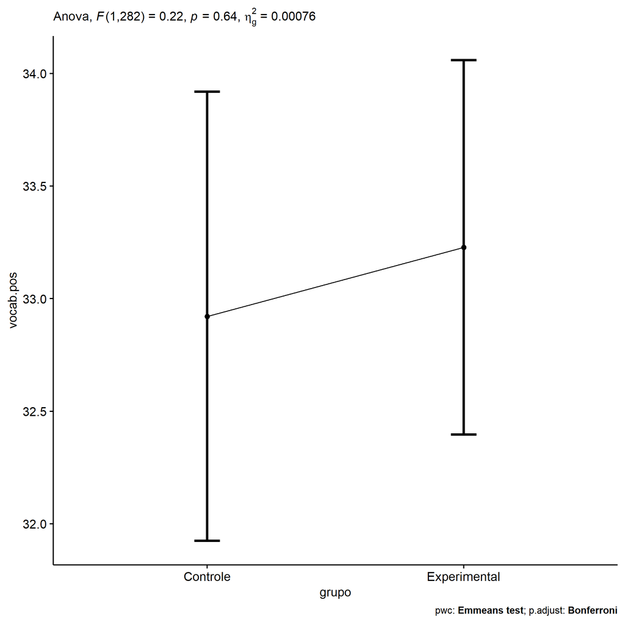

```r
if (!is.null(nrow(plots[["grupo"]]$data)))
  plots[["grupo"]] + ggplot2::scale_color_manual(values = color[["grupo"]])
```

```r
plots <- oneWayAncovaBoxPlots(
  wdat, "vocab.pos", "grupo", aov, pwc, covar = "vocab.pre",
  theme = "classic", color = color[["grupo"]],
  subtitle = which(aov$Effect == "grupo"))
```

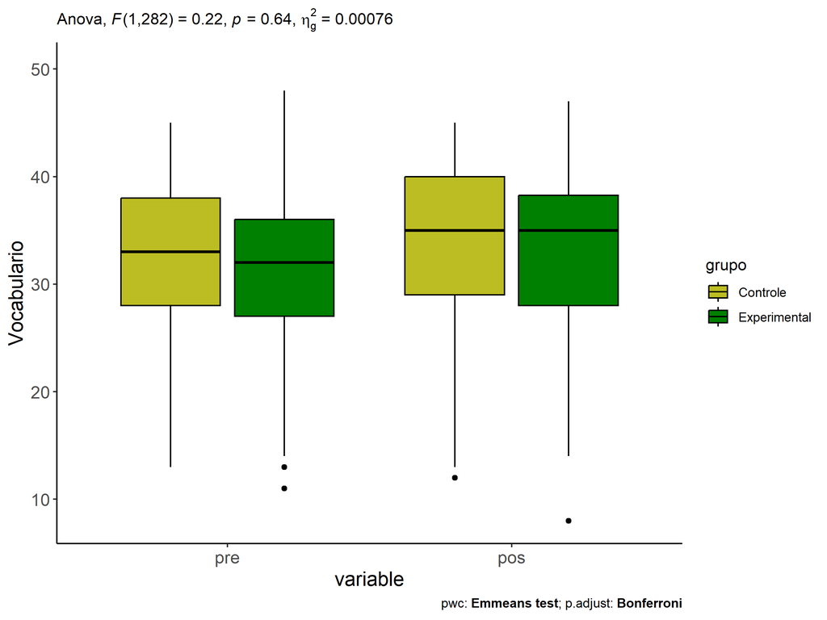

```r
if (length(unique(wdat[["grupo"]])) > 1)
  plots[["grupo"]] + ggplot2::ylab("Vocabulario") + ggplot2::scale_x_discrete(labels=c('pre', 'pos'))
```

```r
if (length(unique(wdat.long[["grupo"]])) > 1)
  plots <- oneWayAncovaBoxPlots(
    wdat.long, "vocab", "grupo", aov, pwc.long, pre.post = "time",
    theme = "classic", color = color$prepost)
```

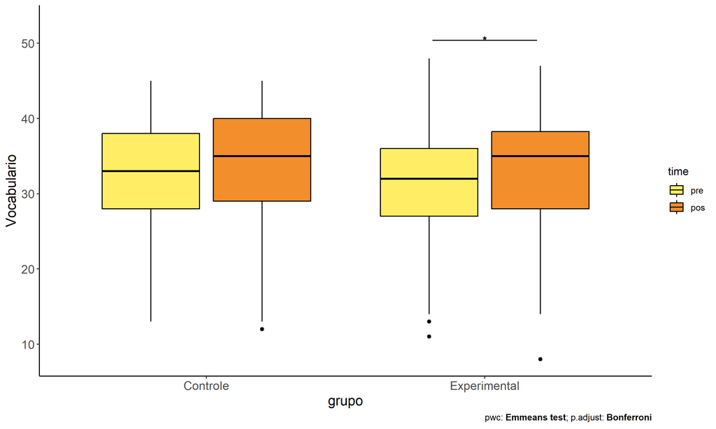

```r
if (length(unique(wdat.long[["grupo"]])) > 1)
  plots[["grupo"]] + ggplot2::ylab("Vocabulario")
```

### Checking linearity assumption

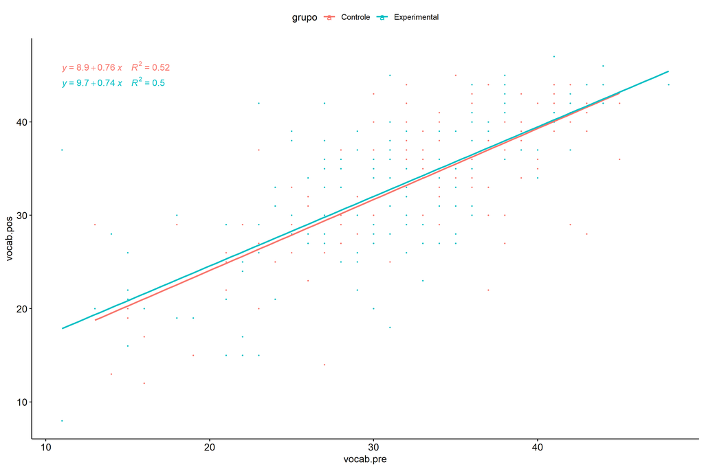

```r
ggscatter(wdat, x = "vocab.pre", y = "vocab.pos", size = 0.5,
          color = "grupo", add = "reg.line")+
  stat_regline_equation(
    aes(label =  paste(..eq.label.., ..rr.label.., sep = "~~~~"), color = grupo)
  )
```

### Checking normality and homogeneity

```r
res <- augment(lm(vocab.pos ~ vocab.pre + grupo, data = wdat))
```

```r
shapiro_test(res$.resid)
```

```
## # A tibble: 1 × 3
##   variable   statistic p.value
##   <chr>          <dbl>   <dbl>
## 1 res$.resid     0.991  0.0869
```

```r
levene_test(res, .resid ~ grupo)
```

```
## # A tibble: 1 × 4
##     df1   df2 statistic     p
##   <int> <int>     <dbl> <dbl>
## 1     1   283   0.00409 0.949
```

# ANCOVA and Pairwise for two factors **grupo:Sexo**

## Without remove non-normal data

```r
pdat = remove_group_data(dat[!is.na(dat[["grupo"]]) & !is.na(dat[["Sexo"]]),], "vocab.pos", c("grupo","Sexo"))

pdat.long <- rbind(pdat[,c("id","grupo","Sexo")], pdat[,c("id","grupo","Sexo")])
pdat.long[["time"]] <- c(rep("pre", nrow(pdat)), rep("pos", nrow(pdat)))
pdat.long[["time"]] <- factor(pdat.long[["time"]], c("pre","pos"))
pdat.long[["vocab"]] <- c(pdat[["vocab.pre"]], pdat[["vocab.pos"]])

aov = anova_test(pdat, vocab.pos ~ vocab.pre + grupo*Sexo)
laov[["grupo:Sexo"]] <- get_anova_table(aov)
```

```r
pwcs <- list()
pwcs[["Sexo"]] <- emmeans_test(
  group_by(pdat, grupo), vocab.pos ~ Sexo,
  covariate = vocab.pre, p.adjust.method = "bonferroni")
pwcs[["grupo"]] <- emmeans_test(
  group_by(pdat, Sexo), vocab.pos ~ grupo,
  covariate = vocab.pre, p.adjust.method = "bonferroni")

pwc <- plyr::rbind.fill(pwcs[["grupo"]], pwcs[["Sexo"]])
pwc <- pwc[,c("grupo","Sexo", colnames(pwc)[!colnames(pwc) %in% c("grupo","Sexo")])]
```

```r
pwc.long <- emmeans_test(dplyr::group_by_at(pdat.long, c("grupo","Sexo")),
                         vocab ~ time,
                         p.adjust.method = "bonferroni")
lpwc[["grupo:Sexo"]] <- plyr::rbind.fill(pwc, pwc.long)
```

```r
ds <- get.descriptives(pdat, "vocab.pos", c("grupo","Sexo"), covar = "vocab.pre")
ds <- merge(ds[ds$variable != "vocab.pre",],
            ds[ds$variable == "vocab.pre", !colnames(ds) %in% c("variable")],
            by = c("grupo","Sexo"), all.x = T, suffixes = c("", ".vocab.pre"))
ds <- merge(get_emmeans(pwcs[["grupo"]]), ds, by = c("grupo","Sexo"), suffixes = c(".emms", ""))
ds <- ds[,c("grupo","Sexo","n","mean.vocab.pre","se.vocab.pre","mean","se","emmean","se.emms")]

colnames(ds) <- c("grupo","Sexo", "N", paste0(c("M","SE")," (pre)"),
                  paste0(c("M","SE"), " (unadj)"), paste0(c("M", "SE"), " (adj)"))

lemms[["grupo:Sexo"]] <- ds
```

## Computing ANCOVA and PairWise After removing non-normal data (OK)

```r
wdat = pdat

res = residuals(lm(vocab.pos ~ vocab.pre + grupo*Sexo, data = wdat))
non.normal = getNonNormal(res, wdat$id, plimit = 0.05)

wdat = wdat[!wdat$id %in% non.normal,]

wdat.long <- rbind(wdat[,c("id","grupo","Sexo")], wdat[,c("id","grupo","Sexo")])
wdat.long[["time"]] <- c(rep("pre", nrow(wdat)), rep("pos", nrow(wdat)))
wdat.long[["time"]] <- factor(wdat.long[["time"]], c("pre","pos"))
wdat.long[["vocab"]] <- c(wdat[["vocab.pre"]], wdat[["vocab.pos"]])


ldat[["grupo:Sexo"]] = wdat

(non.normal)
```

```
## [1] "P1139" "P1113" "P1129" "P2304" "P3260"
```

```r
aov = anova_test(wdat, vocab.pos ~ vocab.pre + grupo*Sexo)
laov[["grupo:Sexo"]] <- merge(get_anova_table(aov), laov[["grupo:Sexo"]], by="Effect", suffixes = c("","'"))

(df = get_anova_table(aov))
```

```
## ANOVA Table (type II tests)
##
##       Effect DFn DFd       F        p p<.05      ges
## 1  vocab.pre   1 279 321.839 2.18e-48     * 0.536000
## 2      grupo   1 279   0.080 7.78e-01       0.000286
## 3       Sexo   1 279   3.469 6.40e-02       0.012000
## 4 grupo:Sexo   1 279   1.206 2.73e-01       0.004000
```

| Effect | DFn | DFd | F | p | p<.05 | ges |
| --- | --- | --- | --- | --- | --- | --- |
| vocab.pre | 1 | 279 | 321.839 | 0.000 | * | 0.536 |
| grupo | 1 | 279 | 0.080 | 0.778 |  | 0.000 |
| Sexo | 1 | 279 | 3.469 | 0.064 |  | 0.012 |
| grupo:Sexo | 1 | 279 | 1.206 | 0.273 |  | 0.004 |

```r
pwcs <- list()
pwcs[["Sexo"]] <- emmeans_test(
  group_by(wdat, grupo), vocab.pos ~ Sexo,
  covariate = vocab.pre, p.adjust.method = "bonferroni")
pwcs[["grupo"]] <- emmeans_test(
  group_by(wdat, Sexo), vocab.pos ~ grupo,
  covariate = vocab.pre, p.adjust.method = "bonferroni")

pwc <- plyr::rbind.fill(pwcs[["grupo"]], pwcs[["Sexo"]])
pwc <- pwc[,c("grupo","Sexo", colnames(pwc)[!colnames(pwc) %in% c("grupo","Sexo")])]
```

| grupo | Sexo | term | .y. | group1 | group2 | df | statistic | p | p.adj | p.adj.signif |
| --- | --- | --- | --- | --- | --- | --- | --- | --- | --- | --- |
|  | F | vocab.pre*grupo | vocab.pos | Controle | Experimental | 279 | -0.981 | 0.327 | 0.327 | ns |
|  | M | vocab.pre*grupo | vocab.pos | Controle | Experimental | 279 | 0.567 | 0.571 | 0.571 | ns |
| Controle |  | vocab.pre*Sexo | vocab.pos | F | M | 279 | 0.354 | 0.724 | 0.724 | ns |
| Experimental |  | vocab.pre*Sexo | vocab.pos | F | M | 279 | 2.133 | 0.034 | 0.034 | * |

```r
pwc.long <- emmeans_test(dplyr::group_by_at(wdat.long, c("grupo","Sexo")),
                         vocab ~ time,
                         p.adjust.method = "bonferroni")
lpwc[["grupo:Sexo"]] <- merge(plyr::rbind.fill(pwc, pwc.long), lpwc[["grupo:Sexo"]], by=c("grupo","Sexo","term",".y.","group1","group2"), suffixes = c("","'"))
```

| grupo | Sexo | term | .y. | group1 | group2 | df | statistic | p | p.adj | p.adj.signif |
| --- | --- | --- | --- | --- | --- | --- | --- | --- | --- | --- |
| Controle | F | time | vocab | pre | pos | 560 | -0.937 | 0.349 | 0.349 | ns |
| Controle | M | time | vocab | pre | pos | 560 | -0.718 | 0.473 | 0.473 | ns |
| Experimental | F | time | vocab | pre | pos | 560 | -2.181 | 0.030 | 0.030 | * |
| Experimental | M | time | vocab | pre | pos | 560 | -0.496 | 0.620 | 0.620 | ns |

```r
ds <- get.descriptives(wdat, "vocab.pos", c("grupo","Sexo"), covar = "vocab.pre")
ds <- merge(ds[ds$variable != "vocab.pre",],
            ds[ds$variable == "vocab.pre", !colnames(ds) %in% c("variable")],
            by = c("grupo","Sexo"), all.x = T, suffixes = c("", ".vocab.pre"))
ds <- merge(get_emmeans(pwcs[["grupo"]]), ds, by = c("grupo","Sexo"), suffixes = c(".emms", ""))
ds <- ds[,c("grupo","Sexo","n","mean.vocab.pre","se.vocab.pre","mean","se","emmean","se.emms")]

colnames(ds) <- c("grupo","Sexo", "N", paste0(c("M","SE")," (pre)"),
                  paste0(c("M","SE"), " (unadj)"), paste0(c("M", "SE"), " (adj)"))

lemms[["grupo:Sexo"]] <- merge(ds, lemms[["grupo:Sexo"]], by=c("grupo","Sexo"), suffixes = c("","'"))
```

| grupo | Sexo | N | M (pre) | SE (pre) | M (unadj) | SE (unadj) | M (adj) | SE (adj) |
| --- | --- | --- | --- | --- | --- | --- | --- | --- |
| Controle | F | 56 | 32.214 | 0.952 | 33.554 | 0.998 | 33.141 | 0.712 |
| Controle | M | 61 | 32.246 | 1.002 | 33.230 | 1.057 | 32.792 | 0.683 |
| Experimental | F | 85 | 30.894 | 0.794 | 33.424 | 0.812 | 34.043 | 0.579 |
| Experimental | M | 82 | 31.732 | 0.775 | 32.317 | 0.884 | 32.282 | 0.588 |

### Plots for ancova

```r
plots <- twoWayAncovaPlots(
  wdat, "vocab.pos", c("grupo","Sexo"), aov, pwcs, addParam = c("mean_se"),
  font.label.size=10, step.increase=0.05, p.label="p.adj",
  subtitle = which(aov$Effect == "grupo:Sexo"))
```

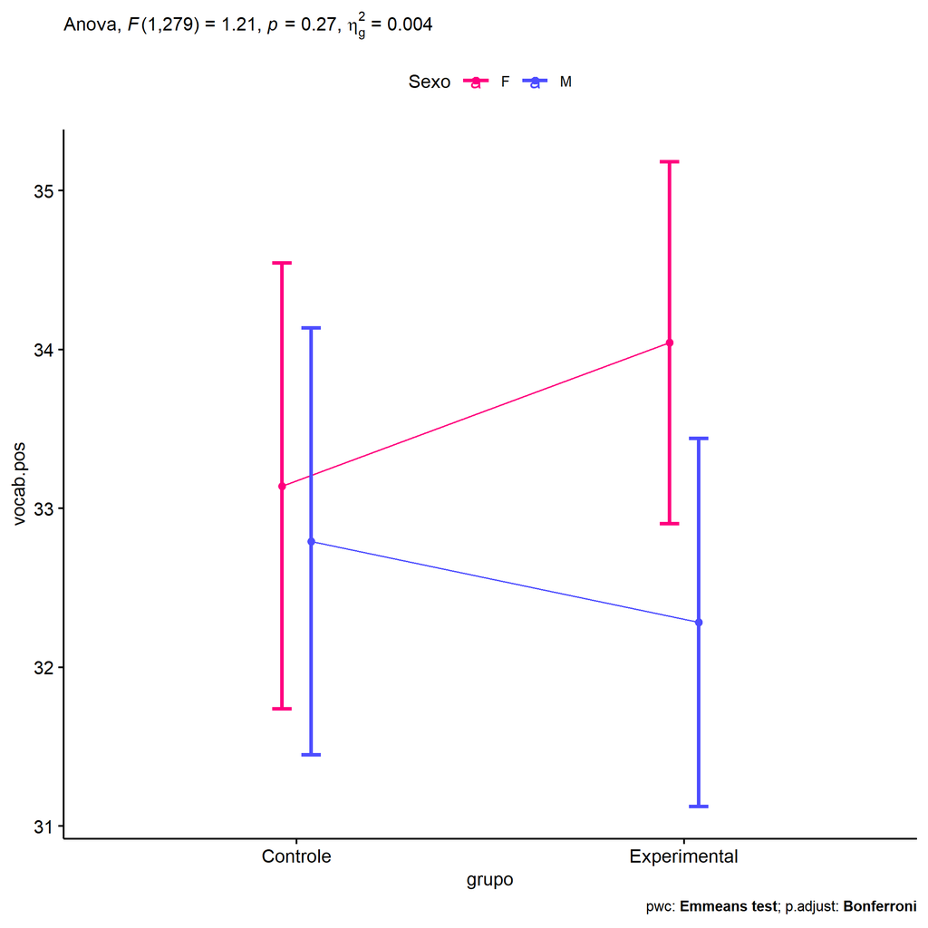

```r
if (!is.null(plots[["grupo"]]))
  plots[["grupo"]] + ggplot2::scale_color_manual(values = color[["Sexo"]])
```

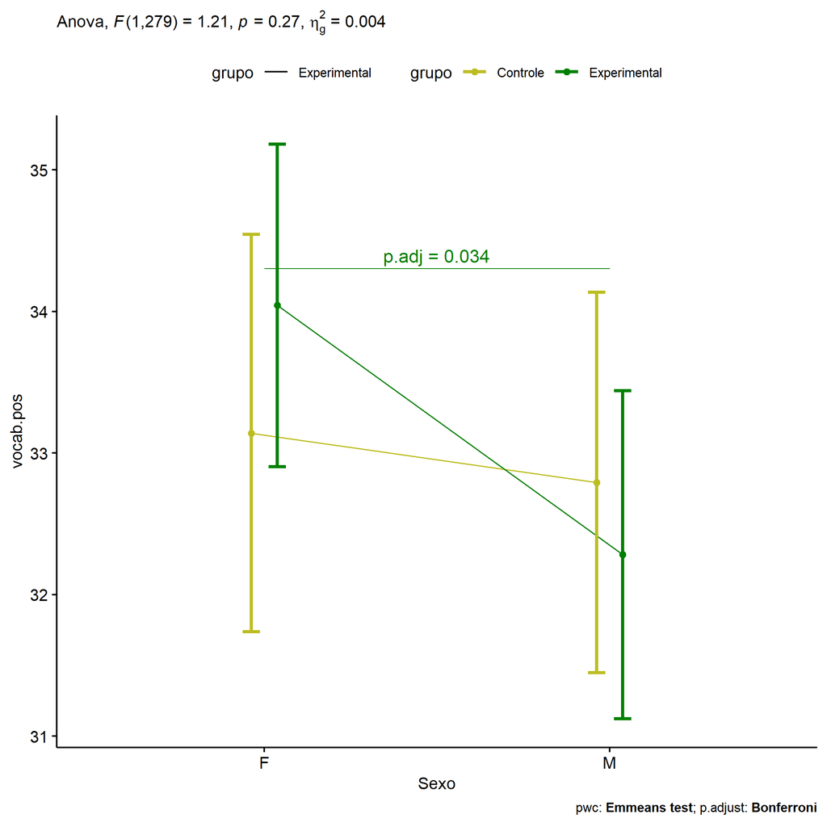

```r
if (!is.null(plots[["Sexo"]]))
  plots[["Sexo"]] + ggplot2::scale_color_manual(values = color[["grupo"]])
```

```r
plots <- twoWayAncovaBoxPlots(
  wdat, "vocab.pos", c("grupo","Sexo"), aov, pwcs, covar = "vocab.pre",
  theme = "classic", color = color[["grupo:Sexo"]],
  subtitle = which(aov$Effect == "grupo:Sexo"))
```

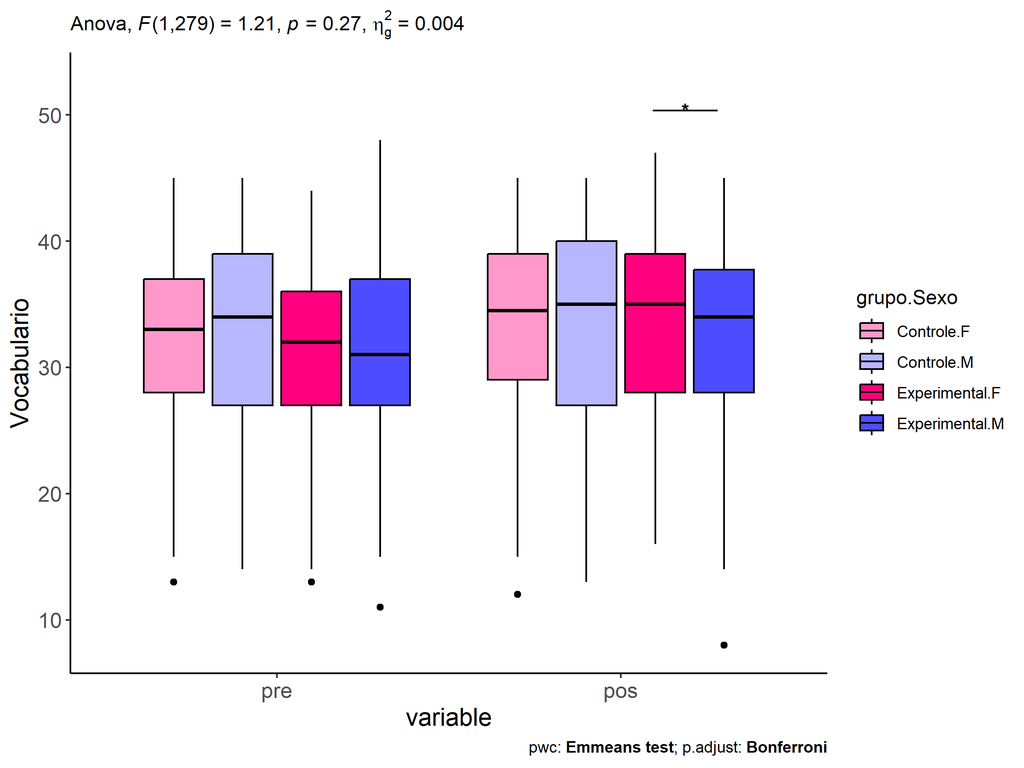

```r
plots[["grupo:Sexo"]] + ggplot2::ylab("Vocabulario") + ggplot2::scale_x_discrete(labels=c('pre', 'pos'))
```

```r
plots <- twoWayAncovaBoxPlots(
  wdat.long, "vocab", c("grupo","Sexo"), aov, pwc.long, pre.post = "time",
  theme = "classic", color = color$prepost)
```

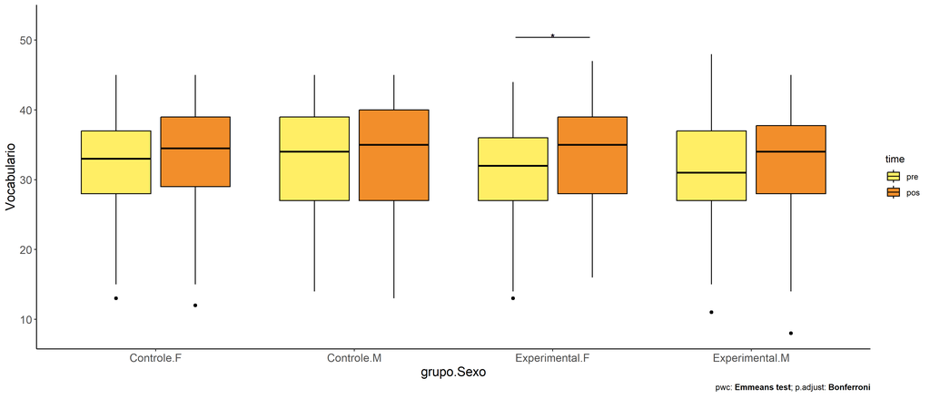

```r
plots[["grupo:Sexo"]] + ggplot2::ylab("Vocabulario")
```

### Checking linearity assumption

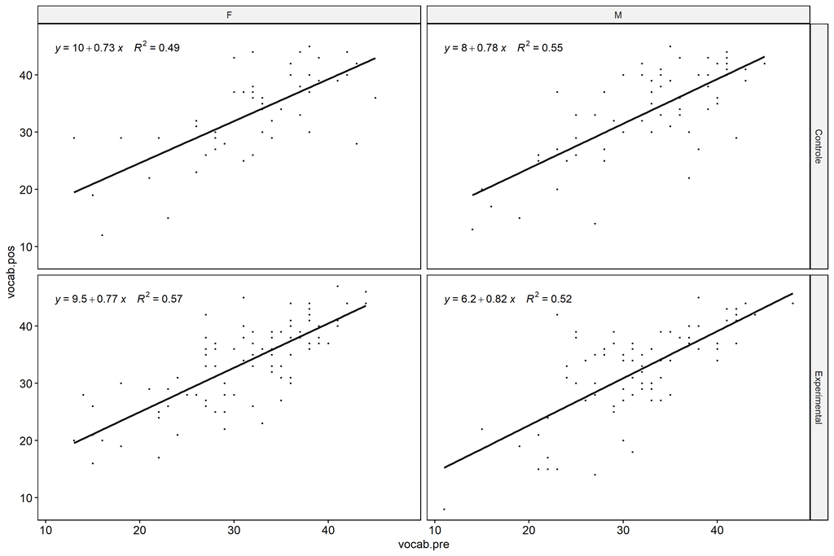

```r
ggscatter(wdat, x = "vocab.pre", y = "vocab.pos", size = 0.5,
          facet.by = c("grupo","Sexo"), add = "reg.line")+
  stat_regline_equation(
    aes(label =  paste(..eq.label.., ..rr.label.., sep = "~~~~"))
  )
```

### Checking normality and homogeneity

```r
res <- augment(lm(vocab.pos ~ vocab.pre + grupo*Sexo, data = wdat))
```

```r
shapiro_test(res$.resid)
```

```
## # A tibble: 1 × 3
##   variable   statistic p.value
##   <chr>          <dbl>   <dbl>
## 1 res$.resid     0.991  0.0914
```

```r
levene_test(res, .resid ~ grupo*Sexo)
```

```
## # A tibble: 1 × 4
##     df1   df2 statistic     p
##   <int> <int>     <dbl> <dbl>
## 1     3   280     0.195 0.900
```

# ANCOVA and Pairwise for two factors **grupo:Zona**

## Without remove non-normal data

```r
pdat = remove_group_data(dat[!is.na(dat[["grupo"]]) & !is.na(dat[["Zona"]]),], "vocab.pos", c("grupo","Zona"))

pdat.long <- rbind(pdat[,c("id","grupo","Zona")], pdat[,c("id","grupo","Zona")])
pdat.long[["time"]] <- c(rep("pre", nrow(pdat)), rep("pos", nrow(pdat)))
pdat.long[["time"]] <- factor(pdat.long[["time"]], c("pre","pos"))
pdat.long[["vocab"]] <- c(pdat[["vocab.pre"]], pdat[["vocab.pos"]])

aov = anova_test(pdat, vocab.pos ~ vocab.pre + grupo*Zona)
laov[["grupo:Zona"]] <- get_anova_table(aov)
```

```r
pwcs <- list()
pwcs[["Zona"]] <- emmeans_test(
  group_by(pdat, grupo), vocab.pos ~ Zona,
  covariate = vocab.pre, p.adjust.method = "bonferroni")
pwcs[["grupo"]] <- emmeans_test(
  group_by(pdat, Zona), vocab.pos ~ grupo,
  covariate = vocab.pre, p.adjust.method = "bonferroni")

pwc <- plyr::rbind.fill(pwcs[["grupo"]], pwcs[["Zona"]])
pwc <- pwc[,c("grupo","Zona", colnames(pwc)[!colnames(pwc) %in% c("grupo","Zona")])]
```

```r
pwc.long <- emmeans_test(dplyr::group_by_at(pdat.long, c("grupo","Zona")),
                         vocab ~ time,
                         p.adjust.method = "bonferroni")
lpwc[["grupo:Zona"]] <- plyr::rbind.fill(pwc, pwc.long)
```

```r
ds <- get.descriptives(pdat, "vocab.pos", c("grupo","Zona"), covar = "vocab.pre")
ds <- merge(ds[ds$variable != "vocab.pre",],
            ds[ds$variable == "vocab.pre", !colnames(ds) %in% c("variable")],
            by = c("grupo","Zona"), all.x = T, suffixes = c("", ".vocab.pre"))
ds <- merge(get_emmeans(pwcs[["grupo"]]), ds, by = c("grupo","Zona"), suffixes = c(".emms", ""))
ds <- ds[,c("grupo","Zona","n","mean.vocab.pre","se.vocab.pre","mean","se","emmean","se.emms")]

colnames(ds) <- c("grupo","Zona", "N", paste0(c("M","SE")," (pre)"),
                  paste0(c("M","SE"), " (unadj)"), paste0(c("M", "SE"), " (adj)"))

lemms[["grupo:Zona"]] <- ds
```

## Computing ANCOVA and PairWise After removing non-normal data (OK)

```r
wdat = pdat

res = residuals(lm(vocab.pos ~ vocab.pre + grupo*Zona, data = wdat))
non.normal = getNonNormal(res, wdat$id, plimit = 0.05)

wdat = wdat[!wdat$id %in% non.normal,]

wdat.long <- rbind(wdat[,c("id","grupo","Zona")], wdat[,c("id","grupo","Zona")])
wdat.long[["time"]] <- c(rep("pre", nrow(wdat)), rep("pos", nrow(wdat)))
wdat.long[["time"]] <- factor(wdat.long[["time"]], c("pre","pos"))
wdat.long[["vocab"]] <- c(wdat[["vocab.pre"]], wdat[["vocab.pos"]])


ldat[["grupo:Zona"]] = wdat

(non.normal)
```

```
## [1] "P1139" "P2304"
```

```r
aov = anova_test(wdat, vocab.pos ~ vocab.pre + grupo*Zona)
laov[["grupo:Zona"]] <- merge(get_anova_table(aov), laov[["grupo:Zona"]], by="Effect", suffixes = c("","'"))

(df = get_anova_table(aov))
```

```
## ANOVA Table (type II tests)
##
##       Effect DFn DFd       F        p p<.05   ges
## 1  vocab.pre   1 156 219.744 1.38e-31     * 0.585
## 2      grupo   1 156   0.337 5.62e-01       0.002
## 3       Zona   1 156   5.437 2.10e-02     * 0.034
## 4 grupo:Zona   1 156   1.332 2.50e-01       0.008
```

| Effect | DFn | DFd | F | p | p<.05 | ges |
| --- | --- | --- | --- | --- | --- | --- |
| vocab.pre | 1 | 156 | 219.744 | 0.000 | * | 0.585 |
| grupo | 1 | 156 | 0.337 | 0.562 |  | 0.002 |
| Zona | 1 | 156 | 5.437 | 0.021 | * | 0.034 |
| grupo:Zona | 1 | 156 | 1.332 | 0.250 |  | 0.008 |

```r
pwcs <- list()
pwcs[["Zona"]] <- emmeans_test(
  group_by(wdat, grupo), vocab.pos ~ Zona,
  covariate = vocab.pre, p.adjust.method = "bonferroni")
pwcs[["grupo"]] <- emmeans_test(
  group_by(wdat, Zona), vocab.pos ~ grupo,
  covariate = vocab.pre, p.adjust.method = "bonferroni")

pwc <- plyr::rbind.fill(pwcs[["grupo"]], pwcs[["Zona"]])
pwc <- pwc[,c("grupo","Zona", colnames(pwc)[!colnames(pwc) %in% c("grupo","Zona")])]
```

| grupo | Zona | term | .y. | group1 | group2 | df | statistic | p | p.adj | p.adj.signif |
| --- | --- | --- | --- | --- | --- | --- | --- | --- | --- | --- |
|  | Rural | vocab.pre*grupo | vocab.pos | Controle | Experimental | 156 | 1.138 | 0.257 | 0.257 | ns |
|  | Urbana | vocab.pre*grupo | vocab.pos | Controle | Experimental | 156 | -0.605 | 0.546 | 0.546 | ns |
| Controle |  | vocab.pre*Zona | vocab.pos | Rural | Urbana | 156 | 2.278 | 0.024 | 0.024 | * |
| Experimental |  | vocab.pre*Zona | vocab.pos | Rural | Urbana | 156 | 1.265 | 0.208 | 0.208 | ns |

```r
pwc.long <- emmeans_test(dplyr::group_by_at(wdat.long, c("grupo","Zona")),
                         vocab ~ time,
                         p.adjust.method = "bonferroni")
lpwc[["grupo:Zona"]] <- merge(plyr::rbind.fill(pwc, pwc.long), lpwc[["grupo:Zona"]], by=c("grupo","Zona","term",".y.","group1","group2"), suffixes = c("","'"))
```

| grupo | Zona | term | .y. | group1 | group2 | df | statistic | p | p.adj | p.adj.signif |
| --- | --- | --- | --- | --- | --- | --- | --- | --- | --- | --- |
| Controle | Rural | time | vocab | pre | pos | 314 | -2.121 | 0.035 | 0.035 | * |
| Controle | Urbana | time | vocab | pre | pos | 314 | 0.022 | 0.982 | 0.982 | ns |
| Experimental | Rural | time | vocab | pre | pos | 314 | -1.952 | 0.052 | 0.052 | ns |
| Experimental | Urbana | time | vocab | pre | pos | 314 | -0.745 | 0.457 | 0.457 | ns |

```r
ds <- get.descriptives(wdat, "vocab.pos", c("grupo","Zona"), covar = "vocab.pre")
ds <- merge(ds[ds$variable != "vocab.pre",],
            ds[ds$variable == "vocab.pre", !colnames(ds) %in% c("variable")],
            by = c("grupo","Zona"), all.x = T, suffixes = c("", ".vocab.pre"))
ds <- merge(get_emmeans(pwcs[["grupo"]]), ds, by = c("grupo","Zona"), suffixes = c(".emms", ""))
ds <- ds[,c("grupo","Zona","n","mean.vocab.pre","se.vocab.pre","mean","se","emmean","se.emms")]

colnames(ds) <- c("grupo","Zona", "N", paste0(c("M","SE")," (pre)"),
                  paste0(c("M","SE"), " (unadj)"), paste0(c("M", "SE"), " (adj)"))

lemms[["grupo:Zona"]] <- merge(ds, lemms[["grupo:Zona"]], by=c("grupo","Zona"), suffixes = c("","'"))
```

| grupo | Zona | N | M (pre) | SE (pre) | M (unadj) | SE (unadj) | M (adj) | SE (adj) |
| --- | --- | --- | --- | --- | --- | --- | --- | --- |
| Controle | Rural | 41 | 31.829 | 0.985 | 35.488 | 1.213 | 35.150 | 0.797 |
| Controle | Urbana | 17 | 33.471 | 1.770 | 33.412 | 2.027 | 31.792 | 1.243 |
| Experimental | Rural | 60 | 30.433 | 1.027 | 33.217 | 1.031 | 33.970 | 0.661 |
| Experimental | Urbana | 43 | 31.512 | 1.331 | 32.767 | 1.175 | 32.678 | 0.778 |

### Plots for ancova

```r
plots <- twoWayAncovaPlots(
  wdat, "vocab.pos", c("grupo","Zona"), aov, pwcs, addParam = c("mean_se"),
  font.label.size=10, step.increase=0.05, p.label="p.adj",
  subtitle = which(aov$Effect == "grupo:Zona"))
```

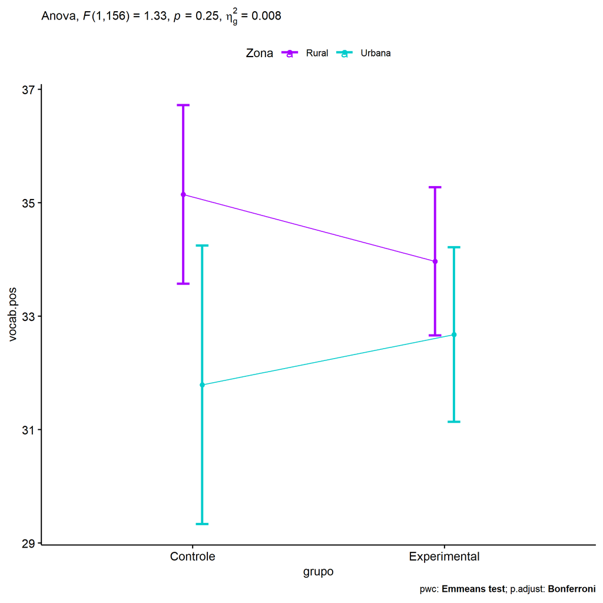

```r
if (!is.null(plots[["grupo"]]))
  plots[["grupo"]] + ggplot2::scale_color_manual(values = color[["Zona"]])
```

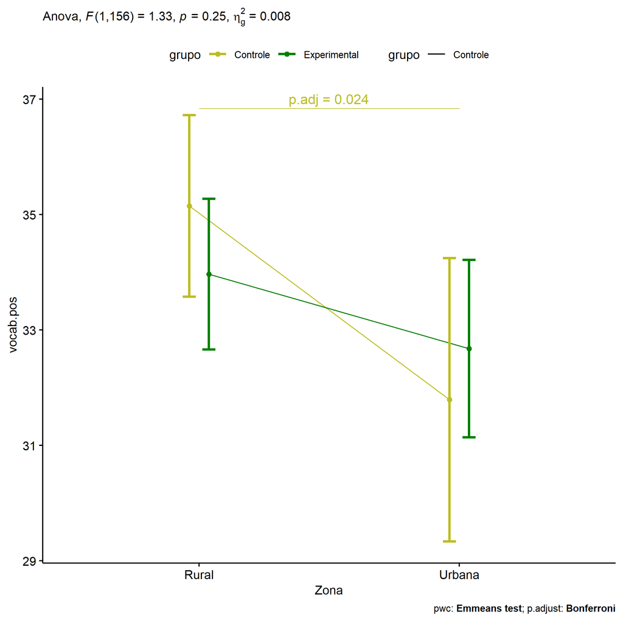

```r
if (!is.null(plots[["Zona"]]))
  plots[["Zona"]] + ggplot2::scale_color_manual(values = color[["grupo"]])
```

```r
plots <- twoWayAncovaBoxPlots(
  wdat, "vocab.pos", c("grupo","Zona"), aov, pwcs, covar = "vocab.pre",
  theme = "classic", color = color[["grupo:Zona"]],
  subtitle = which(aov$Effect == "grupo:Zona"))
```

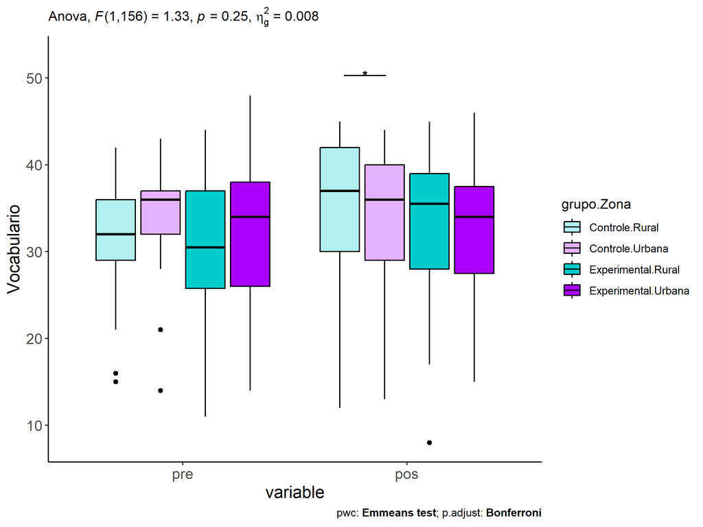

```r
plots[["grupo:Zona"]] + ggplot2::ylab("Vocabulario") + ggplot2::scale_x_discrete(labels=c('pre', 'pos'))
```

```r
plots <- twoWayAncovaBoxPlots(
  wdat.long, "vocab", c("grupo","Zona"), aov, pwc.long, pre.post = "time",
  theme = "classic", color = color$prepost)
```

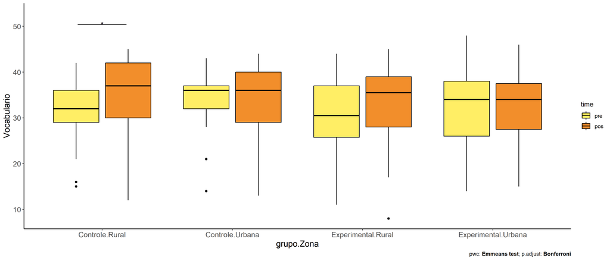

```r
plots[["grupo:Zona"]] + ggplot2::ylab("Vocabulario")
```

### Checking linearity assumption

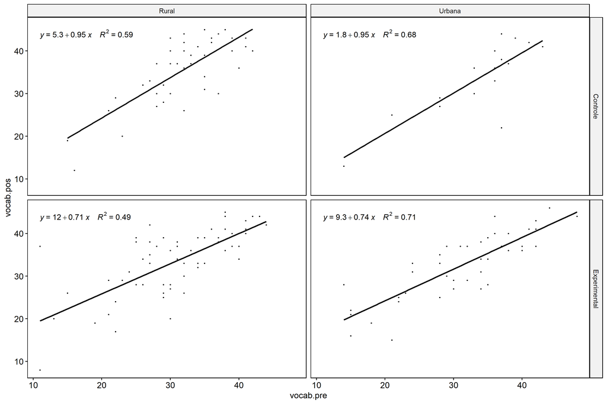

```r
ggscatter(wdat, x = "vocab.pre", y = "vocab.pos", size = 0.5,
          facet.by = c("grupo","Zona"), add = "reg.line")+
  stat_regline_equation(
    aes(label =  paste(..eq.label.., ..rr.label.., sep = "~~~~"))
  )
```

### Checking normality and homogeneity

```r
res <- augment(lm(vocab.pos ~ vocab.pre + grupo*Zona, data = wdat))
```

```r
shapiro_test(res$.resid)
```

```
## # A tibble: 1 × 3
##   variable   statistic p.value
##   <chr>          <dbl>   <dbl>
## 1 res$.resid     0.989   0.260
```

```r
levene_test(res, .resid ~ grupo*Zona)
```

```
## # A tibble: 1 × 4
##     df1   df2 statistic     p
##   <int> <int>     <dbl> <dbl>
## 1     3   157      1.19 0.316
```

# ANCOVA and Pairwise for two factors **grupo:Cor.Raca**

## Without remove non-normal data

```r
pdat = remove_group_data(dat[!is.na(dat[["grupo"]]) & !is.na(dat[["Cor.Raca"]]),], "vocab.pos", c("grupo","Cor.Raca"))

pdat.long <- rbind(pdat[,c("id","grupo","Cor.Raca")], pdat[,c("id","grupo","Cor.Raca")])
pdat.long[["time"]] <- c(rep("pre", nrow(pdat)), rep("pos", nrow(pdat)))
pdat.long[["time"]] <- factor(pdat.long[["time"]], c("pre","pos"))
pdat.long[["vocab"]] <- c(pdat[["vocab.pre"]], pdat[["vocab.pos"]])

aov = anova_test(pdat, vocab.pos ~ vocab.pre + grupo*Cor.Raca)
laov[["grupo:Cor.Raca"]] <- get_anova_table(aov)
```

```r
pwcs <- list()
pwcs[["Cor.Raca"]] <- emmeans_test(
  group_by(pdat, grupo), vocab.pos ~ Cor.Raca,
  covariate = vocab.pre, p.adjust.method = "bonferroni")
pwcs[["grupo"]] <- emmeans_test(
  group_by(pdat, Cor.Raca), vocab.pos ~ grupo,
  covariate = vocab.pre, p.adjust.method = "bonferroni")

pwc <- plyr::rbind.fill(pwcs[["grupo"]], pwcs[["Cor.Raca"]])
pwc <- pwc[,c("grupo","Cor.Raca", colnames(pwc)[!colnames(pwc) %in% c("grupo","Cor.Raca")])]
```

```r
pwc.long <- emmeans_test(dplyr::group_by_at(pdat.long, c("grupo","Cor.Raca")),
                         vocab ~ time,
                         p.adjust.method = "bonferroni")
lpwc[["grupo:Cor.Raca"]] <- plyr::rbind.fill(pwc, pwc.long)
```

```r
ds <- get.descriptives(pdat, "vocab.pos", c("grupo","Cor.Raca"), covar = "vocab.pre")
ds <- merge(ds[ds$variable != "vocab.pre",],
            ds[ds$variable == "vocab.pre", !colnames(ds) %in% c("variable")],
            by = c("grupo","Cor.Raca"), all.x = T, suffixes = c("", ".vocab.pre"))
ds <- merge(get_emmeans(pwcs[["grupo"]]), ds, by = c("grupo","Cor.Raca"), suffixes = c(".emms", ""))
ds <- ds[,c("grupo","Cor.Raca","n","mean.vocab.pre","se.vocab.pre","mean","se","emmean","se.emms")]

colnames(ds) <- c("grupo","Cor.Raca", "N", paste0(c("M","SE")," (pre)"),
                  paste0(c("M","SE"), " (unadj)"), paste0(c("M", "SE"), " (adj)"))

lemms[["grupo:Cor.Raca"]] <- ds
```

## Computing ANCOVA and PairWise After removing non-normal data (OK)

```r
wdat = pdat

res = residuals(lm(vocab.pos ~ vocab.pre + grupo*Cor.Raca, data = wdat))
non.normal = getNonNormal(res, wdat$id, plimit = 0.05)

wdat = wdat[!wdat$id %in% non.normal,]

wdat.long <- rbind(wdat[,c("id","grupo","Cor.Raca")], wdat[,c("id","grupo","Cor.Raca")])
wdat.long[["time"]] <- c(rep("pre", nrow(wdat)), rep("pos", nrow(wdat)))
wdat.long[["time"]] <- factor(wdat.long[["time"]], c("pre","pos"))
wdat.long[["vocab"]] <- c(wdat[["vocab.pre"]], wdat[["vocab.pos"]])


ldat[["grupo:Cor.Raca"]] = wdat

(non.normal)
```

```
## [1] "P1113" "P1139" "P3260" "P3265" "P1112"
```

```r
aov = anova_test(wdat, vocab.pos ~ vocab.pre + grupo*Cor.Raca)
laov[["grupo:Cor.Raca"]] <- merge(get_anova_table(aov), laov[["grupo:Cor.Raca"]], by="Effect", suffixes = c("","'"))

(df = get_anova_table(aov))
```

```
## ANOVA Table (type II tests)
##
##           Effect DFn DFd       F        p p<.05   ges
## 1      vocab.pre   1 106 168.326 1.27e-23     * 0.614
## 2          grupo   1 106   0.403 5.27e-01       0.004
## 3       Cor.Raca   1 106   1.734 1.91e-01       0.016
## 4 grupo:Cor.Raca   1 106   2.645 1.07e-01       0.024
```

| Effect | DFn | DFd | F | p | p<.05 | ges |
| --- | --- | --- | --- | --- | --- | --- |
| vocab.pre | 1 | 106 | 168.326 | 0.000 | * | 0.614 |
| grupo | 1 | 106 | 0.403 | 0.527 |  | 0.004 |
| Cor.Raca | 1 | 106 | 1.734 | 0.191 |  | 0.016 |
| grupo:Cor.Raca | 1 | 106 | 2.645 | 0.107 |  | 0.024 |

```r
pwcs <- list()
pwcs[["Cor.Raca"]] <- emmeans_test(
  group_by(wdat, grupo), vocab.pos ~ Cor.Raca,
  covariate = vocab.pre, p.adjust.method = "bonferroni")
pwcs[["grupo"]] <- emmeans_test(
  group_by(wdat, Cor.Raca), vocab.pos ~ grupo,
  covariate = vocab.pre, p.adjust.method = "bonferroni")

pwc <- plyr::rbind.fill(pwcs[["grupo"]], pwcs[["Cor.Raca"]])
pwc <- pwc[,c("grupo","Cor.Raca", colnames(pwc)[!colnames(pwc) %in% c("grupo","Cor.Raca")])]
```

| grupo | Cor.Raca | term | .y. | group1 | group2 | df | statistic | p | p.adj | p.adj.signif |
| --- | --- | --- | --- | --- | --- | --- | --- | --- | --- | --- |
|  | Branca | vocab.pre*grupo | vocab.pos | Controle | Experimental | 106 | 1.224 | 0.224 | 0.224 | ns |
|  | Parda | vocab.pre*grupo | vocab.pos | Controle | Experimental | 106 | -1.246 | 0.216 | 0.216 | ns |
| Controle |  | vocab.pre*Cor.Raca | vocab.pos | Branca | Parda | 106 | 2.093 | 0.039 | 0.039 | * |
| Experimental |  | vocab.pre*Cor.Raca | vocab.pos | Branca | Parda | 106 | 0.064 | 0.949 | 0.949 | ns |

```r
pwc.long <- emmeans_test(dplyr::group_by_at(wdat.long, c("grupo","Cor.Raca")),
                         vocab ~ time,
                         p.adjust.method = "bonferroni")
lpwc[["grupo:Cor.Raca"]] <- merge(plyr::rbind.fill(pwc, pwc.long), lpwc[["grupo:Cor.Raca"]], by=c("grupo","Cor.Raca","term",".y.","group1","group2"), suffixes = c("","'"))
```

| grupo | Cor.Raca | term | .y. | group1 | group2 | df | statistic | p | p.adj | p.adj.signif |
| --- | --- | --- | --- | --- | --- | --- | --- | --- | --- | --- |
| Controle | Branca | time | vocab | pre | pos | 214 | -1.232 | 0.219 | 0.219 | ns |
| Controle | Parda | time | vocab | pre | pos | 214 | -0.704 | 0.482 | 0.482 | ns |
| Experimental | Branca | time | vocab | pre | pos | 214 | -0.709 | 0.479 | 0.479 | ns |
| Experimental | Parda | time | vocab | pre | pos | 214 | -1.671 | 0.096 | 0.096 | ns |

```r
ds <- get.descriptives(wdat, "vocab.pos", c("grupo","Cor.Raca"), covar = "vocab.pre")
ds <- merge(ds[ds$variable != "vocab.pre",],
            ds[ds$variable == "vocab.pre", !colnames(ds) %in% c("variable")],
            by = c("grupo","Cor.Raca"), all.x = T, suffixes = c("", ".vocab.pre"))
ds <- merge(get_emmeans(pwcs[["grupo"]]), ds, by = c("grupo","Cor.Raca"), suffixes = c(".emms", ""))
ds <- ds[,c("grupo","Cor.Raca","n","mean.vocab.pre","se.vocab.pre","mean","se","emmean","se.emms")]

colnames(ds) <- c("grupo","Cor.Raca", "N", paste0(c("M","SE")," (pre)"),
                  paste0(c("M","SE"), " (unadj)"), paste0(c("M", "SE"), " (adj)"))

lemms[["grupo:Cor.Raca"]] <- merge(ds, lemms[["grupo:Cor.Raca"]], by=c("grupo","Cor.Raca"), suffixes = c("","'"))
```

| grupo | Cor.Raca | N | M (pre) | SE (pre) | M (unadj) | SE (unadj) | M (adj) | SE (adj) |
| --- | --- | --- | --- | --- | --- | --- | --- | --- |
| Controle | Branca | 7 | 34.000 | 1.480 | 39.286 | 1.209 | 36.354 | 2.006 |
| Controle | Parda | 44 | 30.591 | 1.097 | 31.795 | 1.265 | 31.838 | 0.795 |
| Experimental | Branca | 13 | 34.231 | 1.791 | 36.462 | 2.120 | 33.328 | 1.482 |
| Experimental | Parda | 47 | 29.191 | 1.232 | 31.957 | 1.332 | 33.221 | 0.775 |

### Plots for ancova

```r
plots <- twoWayAncovaPlots(
  wdat, "vocab.pos", c("grupo","Cor.Raca"), aov, pwcs, addParam = c("mean_se"),
  font.label.size=10, step.increase=0.05, p.label="p.adj",
  subtitle = which(aov$Effect == "grupo:Cor.Raca"))
```

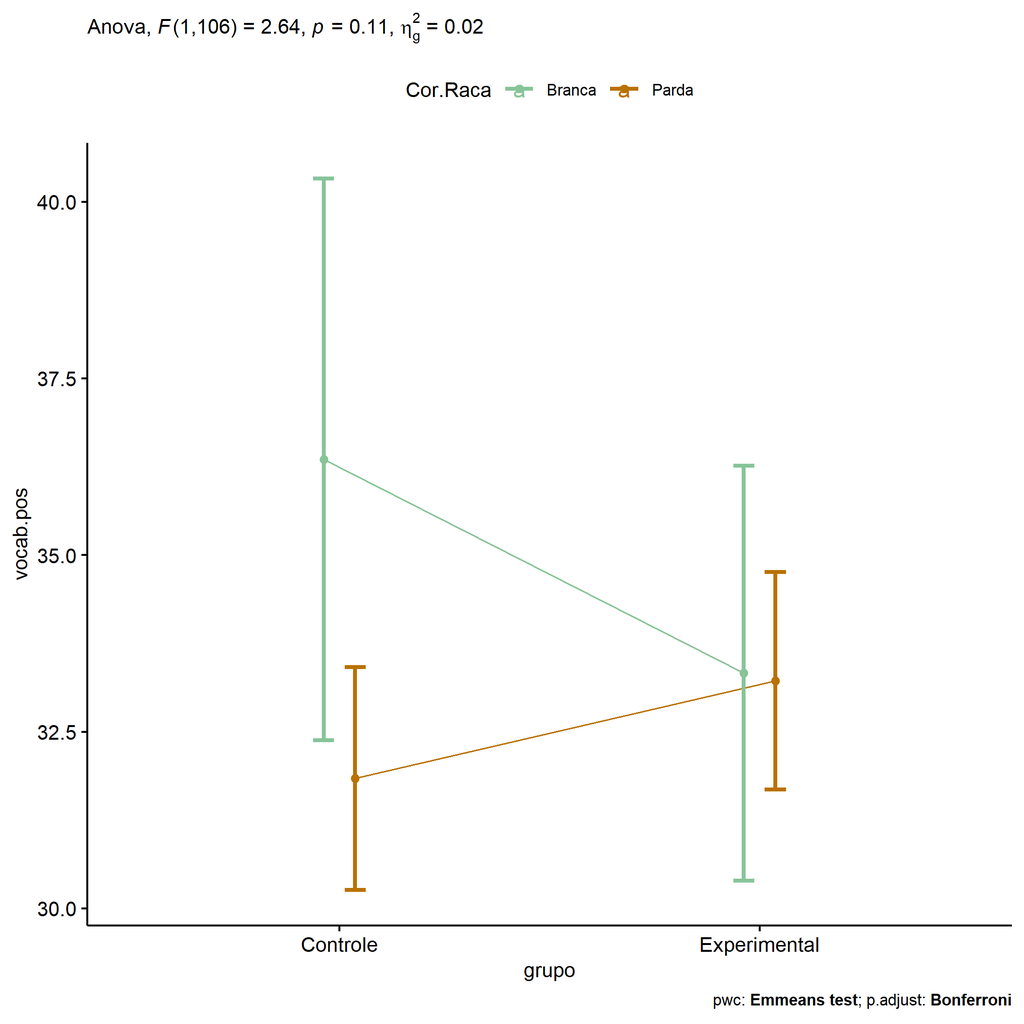

```r
if (!is.null(plots[["grupo"]]))
  plots[["grupo"]] + ggplot2::scale_color_manual(values = color[["Cor.Raca"]])
```

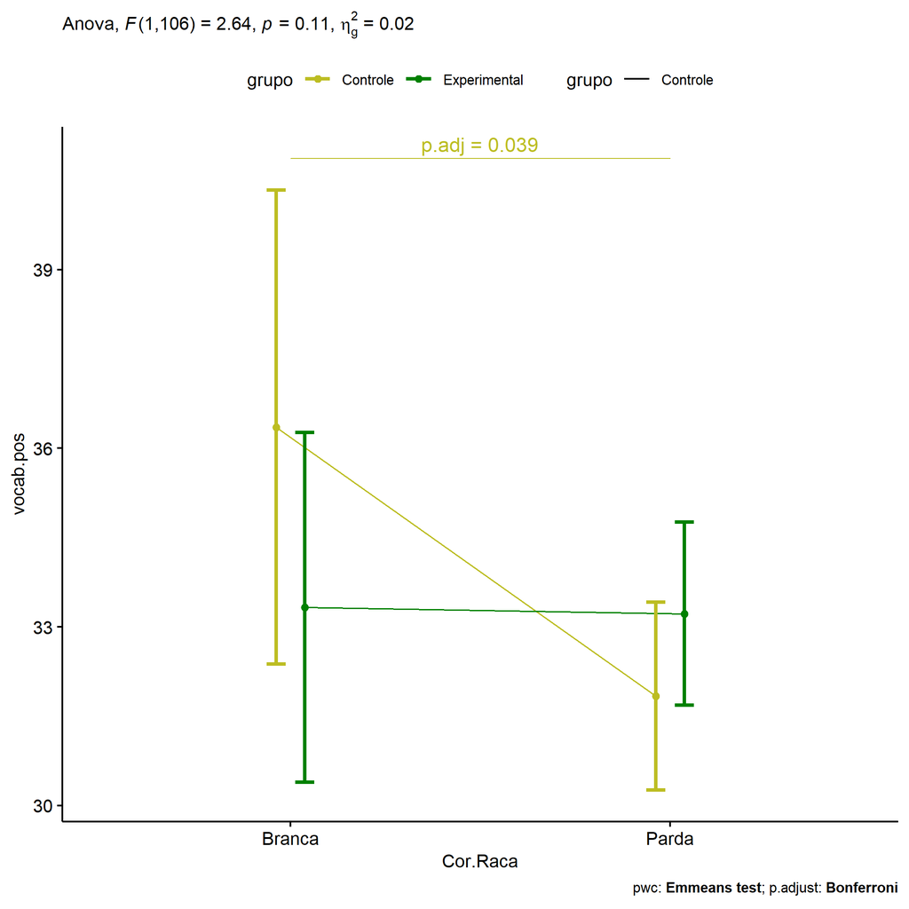

```r
if (!is.null(plots[["Cor.Raca"]]))
  plots[["Cor.Raca"]] + ggplot2::scale_color_manual(values = color[["grupo"]])
```

```r
plots <- twoWayAncovaBoxPlots(
  wdat, "vocab.pos", c("grupo","Cor.Raca"), aov, pwcs, covar = "vocab.pre",
  theme = "classic", color = color[["grupo:Cor.Raca"]],
  subtitle = which(aov$Effect == "grupo:Cor.Raca"))
```

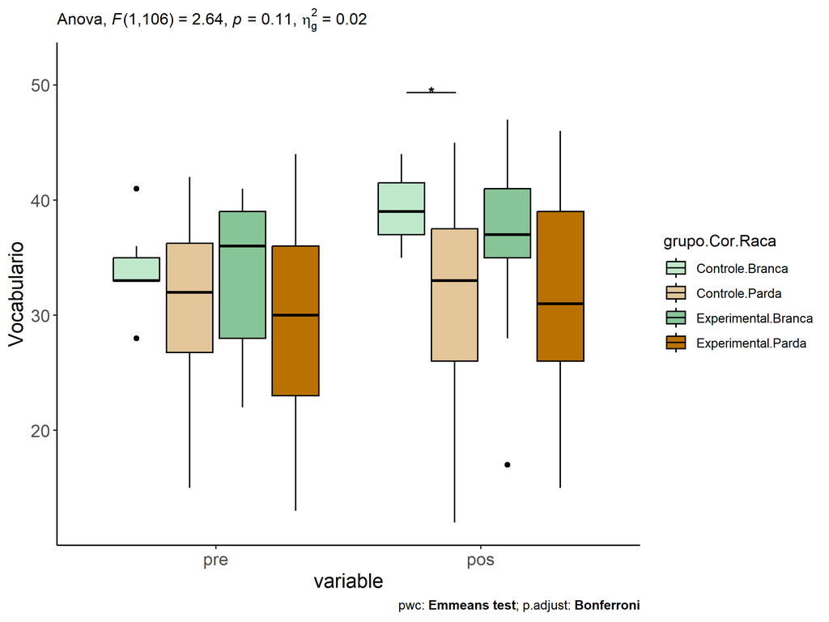

```r
plots[["grupo:Cor.Raca"]] + ggplot2::ylab("Vocabulario") + ggplot2::scale_x_discrete(labels=c('pre', 'pos'))
```

```r
plots <- twoWayAncovaBoxPlots(
  wdat.long, "vocab", c("grupo","Cor.Raca"), aov, pwc.long, pre.post = "time",
  theme = "classic", color = color$prepost)
```

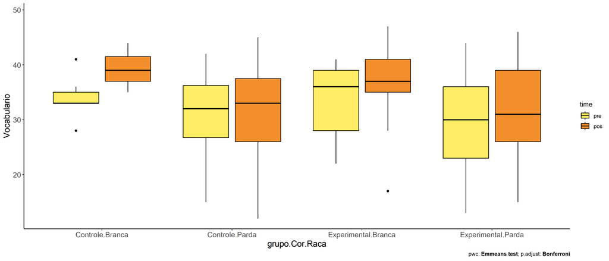

```r
plots[["grupo:Cor.Raca"]] + ggplot2::ylab("Vocabulario")
```

### Checking linearity assumption

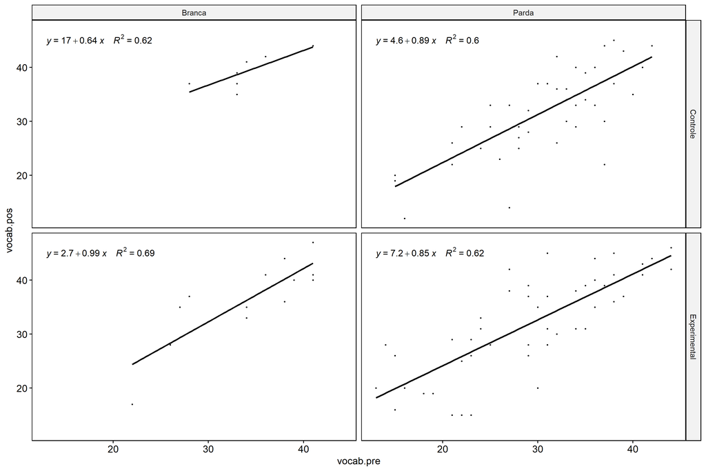

```r
ggscatter(wdat, x = "vocab.pre", y = "vocab.pos", size = 0.5,
          facet.by = c("grupo","Cor.Raca"), add = "reg.line")+
  stat_regline_equation(
    aes(label =  paste(..eq.label.., ..rr.label.., sep = "~~~~"))
  )
```

### Checking normality and homogeneity

```r
res <- augment(lm(vocab.pos ~ vocab.pre + grupo*Cor.Raca, data = wdat))
```

```r
shapiro_test(res$.resid)
```

```
## # A tibble: 1 × 3
##   variable   statistic p.value
##   <chr>          <dbl>   <dbl>
## 1 res$.resid     0.982   0.149
```

```r
levene_test(res, .resid ~ grupo*Cor.Raca)
```

```
## # A tibble: 1 × 4
##     df1   df2 statistic     p
##   <int> <int>     <dbl> <dbl>
## 1     3   107      1.66 0.180
```

# ANCOVA and Pairwise for two factors **grupo:vocab.quintile**

## Without remove non-normal data

```r
pdat = remove_group_data(dat[!is.na(dat[["grupo"]]) & !is.na(dat[["vocab.quintile"]]),], "vocab.pos", c("grupo","vocab.quintile"))

pdat.long <- rbind(pdat[,c("id","grupo","vocab.quintile")], pdat[,c("id","grupo","vocab.quintile")])
pdat.long[["time"]] <- c(rep("pre", nrow(pdat)), rep("pos", nrow(pdat)))
pdat.long[["time"]] <- factor(pdat.long[["time"]], c("pre","pos"))
pdat.long[["vocab"]] <- c(pdat[["vocab.pre"]], pdat[["vocab.pos"]])

aov = anova_test(pdat, vocab.pos ~ vocab.pre + grupo*vocab.quintile)
laov[["grupo:vocab.quintile"]] <- get_anova_table(aov)
```

```r
pwcs <- list()
pwcs[["vocab.quintile"]] <- emmeans_test(
  group_by(pdat, grupo), vocab.pos ~ vocab.quintile,
  covariate = vocab.pre, p.adjust.method = "bonferroni")
pwcs[["grupo"]] <- emmeans_test(
  group_by(pdat, vocab.quintile), vocab.pos ~ grupo,
  covariate = vocab.pre, p.adjust.method = "bonferroni")

pwc <- plyr::rbind.fill(pwcs[["grupo"]], pwcs[["vocab.quintile"]])
pwc <- pwc[,c("grupo","vocab.quintile", colnames(pwc)[!colnames(pwc) %in% c("grupo","vocab.quintile")])]
```

```r
pwc.long <- emmeans_test(dplyr::group_by_at(pdat.long, c("grupo","vocab.quintile")),
                         vocab ~ time,
                         p.adjust.method = "bonferroni")
lpwc[["grupo:vocab.quintile"]] <- plyr::rbind.fill(pwc, pwc.long)
```

```r
ds <- get.descriptives(pdat, "vocab.pos", c("grupo","vocab.quintile"), covar = "vocab.pre")
ds <- merge(ds[ds$variable != "vocab.pre",],
            ds[ds$variable == "vocab.pre", !colnames(ds) %in% c("variable")],
            by = c("grupo","vocab.quintile"), all.x = T, suffixes = c("", ".vocab.pre"))
ds <- merge(get_emmeans(pwcs[["grupo"]]), ds, by = c("grupo","vocab.quintile"), suffixes = c(".emms", ""))
ds <- ds[,c("grupo","vocab.quintile","n","mean.vocab.pre","se.vocab.pre","mean","se","emmean","se.emms")]

colnames(ds) <- c("grupo","vocab.quintile", "N", paste0(c("M","SE")," (pre)"),
                  paste0(c("M","SE"), " (unadj)"), paste0(c("M", "SE"), " (adj)"))

lemms[["grupo:vocab.quintile"]] <- ds
```